# (Ford GoBike System Data)

## by (Amal Aljabri)

## Investigation Overview

In this investigation, I wanted to look at the characteristics of Ford GoBike system data covering the greater San Francisco Bay area. The main focus was on days of the week, hours of the day, trip duration, user type, user age, and gender.

## Dataset Overview

The dataset includes information about individual rides made in a bike-sharing system covering the greater San Francisco Bay area.

## Number of bike trips used per week day

The number of bike trips is higher on work days (Monday, Tuesday, Wednesday, Thursday, Friday) and lower on weekends days (Saturday, Sunday) in San Francisco.

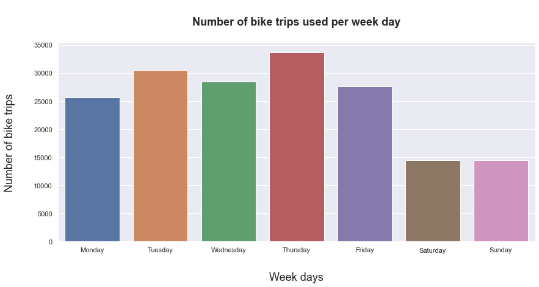

## Distribution of bike trips used per day hour

The distribution of bike trips used per day hour is popular between 8-9 AM and 4-6 PM.

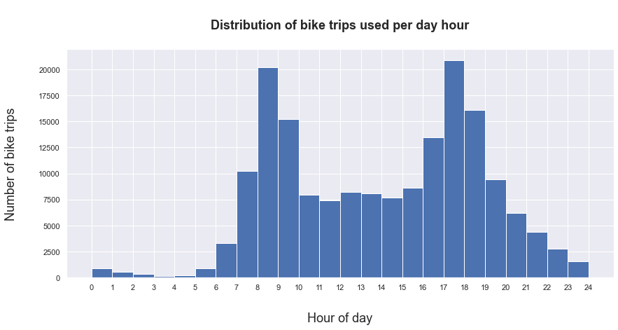

## Gender distribution of bike trips

The gender distribution of bike trips was (74.6%) are males, while females are (23.3%).

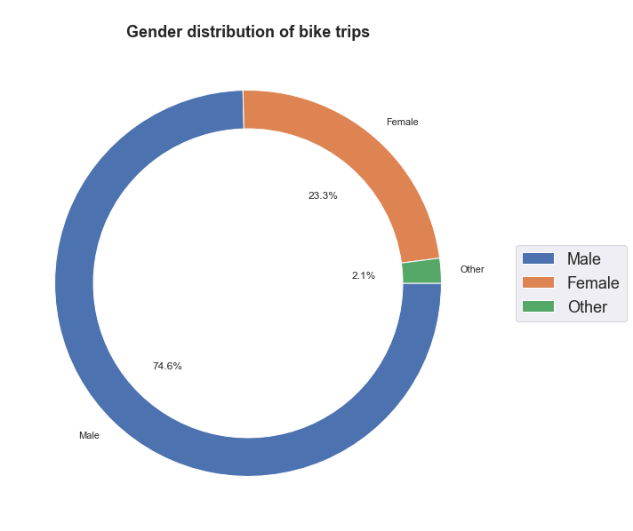

## User types distribution of bike trips

The user types distribution of bike trips was (90.5%) are subscriber, while customer are (9.5%).

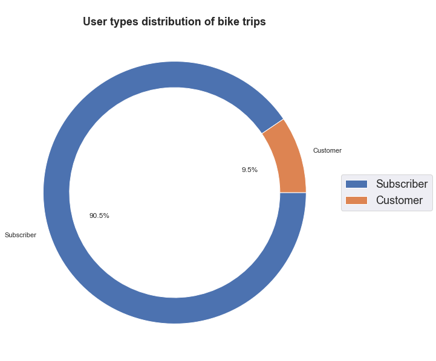

## Average bike trip duration in minutes per user type

The average bike trip duration in minutes per user type was (10.679922) are subscriber, while customer are (21.847536).

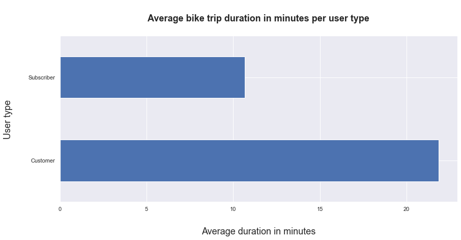

## Distribution of bike trip duration in minutes per user type

The distribution of bike trip duration in minutes per user type was the distribution of customer trip time shows more variability than subscribers.

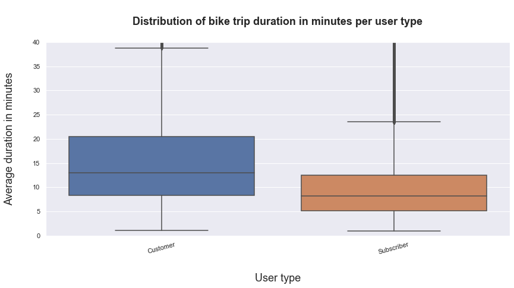

## Number of bike trips gender per user type

The number of bike trips gender per user type was a subscribers bigger than customers.

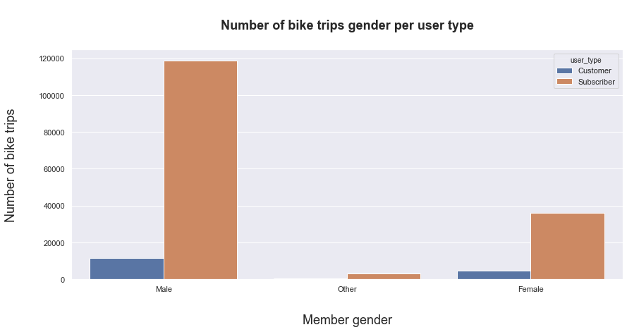

## Customer vs. Subscriber frequency of bike trips used per week day

The number of bike trips for subscribers is higher on work days (Monday, Tuesday, Wednesday, Thursday, Friday) and lower on weekends days (Saturday, Sunday) in San Francisco.

The number of bike trips for customers is consistent on all week days in San Francisco.

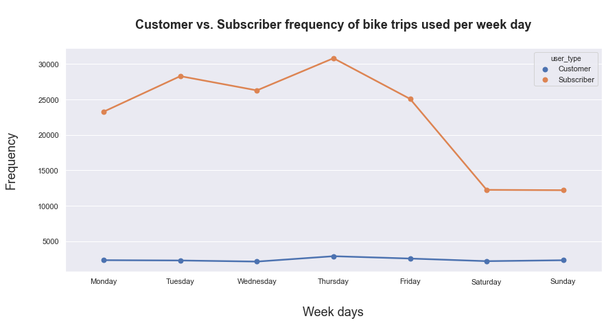

## The relation between the hour of day, bike trip duration in seconds, and member gender

Male customers take longer bike trips than female customers.

Males take long bike trips from 11 AM to 4 PM.

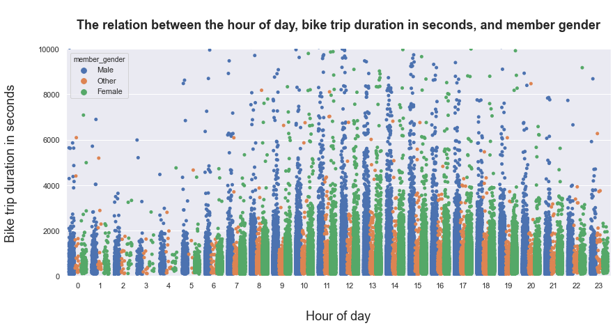

## The relation between the hour of day, bike trip duration in seconds, and user type

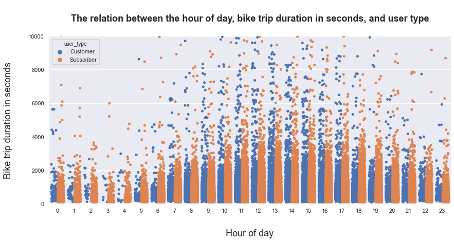